# A3: SPL Library Checkouts

### Introduction

The following is based off the public data set provided by the Seattle Public Library. Due to the sheer size of the data, this specific report uses the data filtered to items that have been checked out more than 10 times from 2017-2023.

The first chart is inspired by J.K. Rowling’s popular series “Harry Potter”. This series has become well known to all since its first appearance in 1998 as a book series and its film adaption in 2001. Since some time has passed since then, just how popular is the series now? By using checkout data from 2022 on both books and discs, I attempt to answer this question and find out which media with Harry Potter content is more consumed.

The second chart aims to analyze the trends on the three different kinds of books, physical, audiobooks, and ebooks, between 2017 and 2023 based on total checkouts. How has technology and world events affected these numbers, even if at all?

The last chart compares what books were popular each year between 2017 and 2023 based on number of checkouts by title. This visualization also demonstrates just how popular each book was compared to the other. Can we connect the data to known world events that triggered their popularity?

### Summary Information

Many people underestimate the resources that the library provides. Some say that with the direction the technology is going, the internet may be all we need and libraries will no longer serve a purpose. To demonstrate that this is not the case at all, here are the total amount of digital and physical items that were checked out from in 2017 and 2022:

**Total Digital and Physical Checkouts For 2017 and 2022**

| Year | Usage Class | Checkouts |
| --- | --- | --- |
| 2017 | Digital | 756,756 |
| 2017 | Physical | 2,763,572 |
| 2022 | Digital | 1,962,294 |
| 2022 | Physical | 1,094,618 |

While physical items are being checked out by almost half the amount they once were, digital checkouts have increased by almost 2.6 times. The Seattle Public Library has done an excellent job of keeping up with technological changes and continuing to provide accessible resources.

To get more familiar with this data set, a table has been created to demonstrate the average number of particular items using checkout data from 2017-2023

**Average Yearly Checkouts For Specific Material Types**

| Material Type | Average Number of Checkouts |
| --- | --- |
| AUDIOBOOK | 532,667 |
| BOOK | 913,995 |
| EBOOK | 721,888 |
| MAGAZINE | 53,827 |
| MUSIC | 1,784 |
| SOUNDDISC | 38,125 |
| VIDEODISC | 475,222 |

Books seem to be, on average, the most checked out material type with eBooks as the second. The least checked out material type between these 7 seem to be music.

### The Dataset

- Who collected/published the data?
  - This data was published by Seattle Public Library.
- What are the parameters of the data (dates, number of checkouts, kinds of books, etc.)?
  - The parameters of the data are UsageClass, CheckoutType, MaterialType, CheckoutYear, CheckoutMonth, Checkouts, Title, ISBN, Creator, Subjects, Publisher, and PublicationYear.
- How was the data collected or generated?
  - The data was generated through various current and historical sources. Overdrive, Hoopla, Freegal, FBDigital provide data on digital items. Legrady Atrwork Data Archive sourced the physical item data from April 2005 to September 2016. Horizon ILS reports the rest f the physical checkout data from October 2016 on. It is updated monthly.
- Why was the data collected?
  - The data was collected to find trends within all this information. From this, the library can work to better their services to the community it serves.
- What, if any, ethical questions do you need to consider when working with this data?
  - Is it possible that any numbers were exaggerated or under reported to create a false trend by certain data providers?
  - Are creators getting the proper acknowledgment when the “Creator” column has no data for a specific row?
- What are possible limitations or problems with this data? (at least 200 words)
  - A possible limitation with this data is that it does not provide information about who exactly is checking out what item. This data can be used to identify what resources the community is in most need of and this can be potentially be even more helpful if it provided the age group potentially of who checked out what. However, this may be a violation of a library users privacy.
  - A problem with this data set is that it also does not include renewals. This could help provide data on how popular a item is.
  - This data set has missing values in some important columns such as published year. This can cause problems when trying to accurately reference a certain item or correctly calculate relevant values. It also can result in not accrediting a creator properly.
  - Sometimes creators are listed in the “Title” column rather than the “Creator” column. This may cause issues when trying to sort by specific creators.
  - There are many variations in publication date. While the FAQ section of the Seattle Public Library clarify them, it may make bring up problems when trying to sort the data.
  - A limitation that needs to be considered is how the library functioned in 2020 due to Covid-19. It was simply impossible to checkout certain items during this time due to the necessary precautions that needed to be taken. This may have included the closure of libraries and the general wariness of checking out materials a person with Covid-19 could have previously borrowed.

### First Trends Over Time Chart

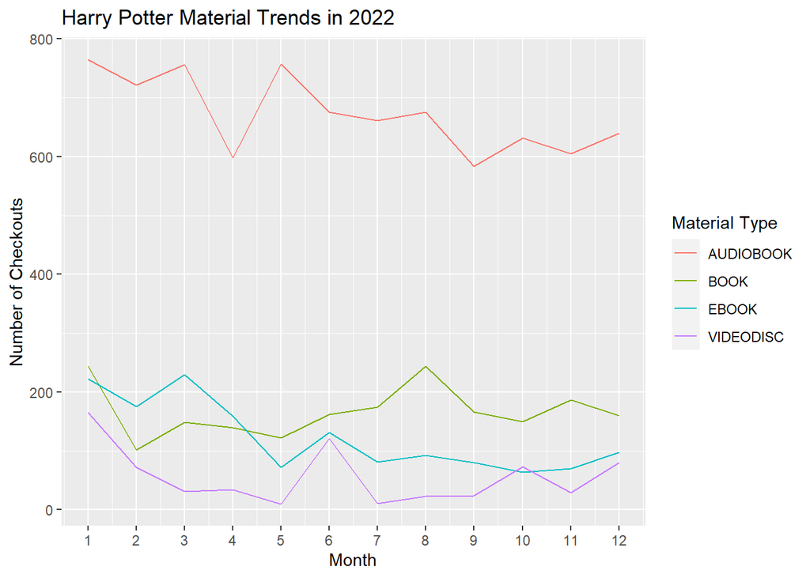

- Purpose:
  - This chart was created to understand the relevance of J.K. Rowlings’s wizarding world of Harry Potter in 2022 and what media library users prefer. A line chart was used to clearly demonstrate trends over time. The month is demonstrated over the x-axis with the number of checkouts serving as the y-axis. Each line is a different color to easily identify the material type.
- Trends:
  - There was a general decrease across all material types regarding Harry Potter. This may indicate that as time goes on, the series is getting more and more unpopular.
  - From the chart, it is clear to see that audio books are the most preferred media to get through the book series. This is understandable due to how long each book is.
  - The movies are the least popular out of all the media type. The chart suggests that people prefer the book series over the movie series.
  - There was an overall decrease in the amount of videodiscs checkout throughout the year. This was the year that major streaming services, such as Hulu and Peacock, introduced the film series to their platform. This trend could potentially be credited to this.

### Second Trends Over Time Chart

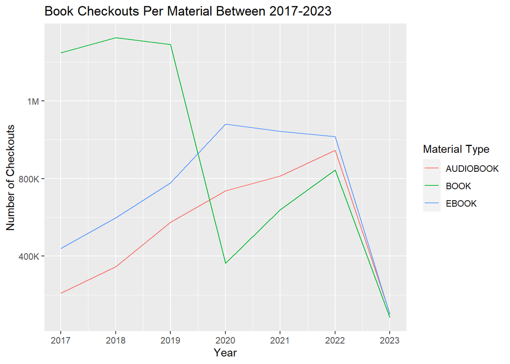

### Your Choice

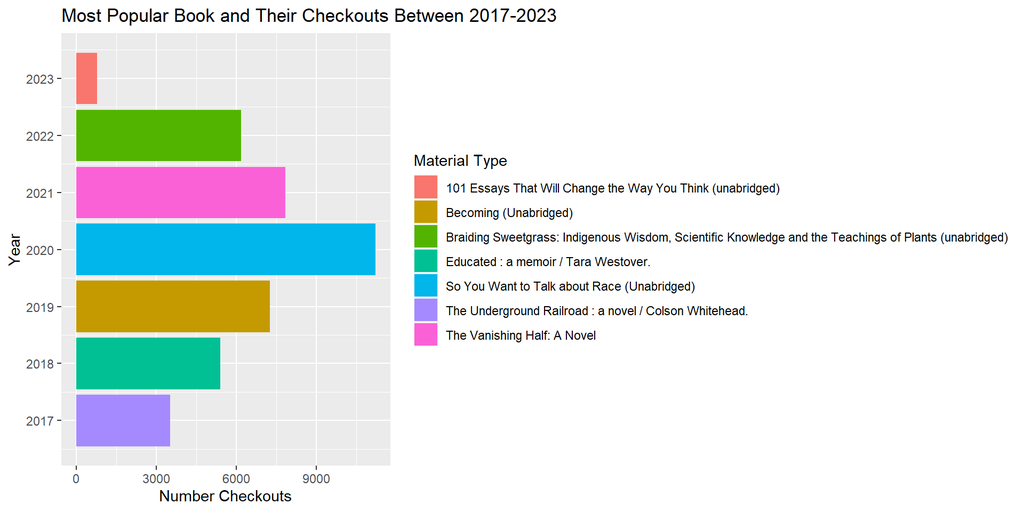